# Analysis of The Programme for International Student Assessment (PISA) 2012 study

## by Aakar Shah

## Preliminary Wrangling

> PISA is a worldwide study developed by the Organisation for Economic Co-operation and Development (OECD) to examine the skills of 15-year-old school students around the world. The study assesses students’ maths, science, and reading skills and contains a wealth of information on students’ background, their school and the organisation of the education system. For most countries, the sample is around 5,000 students, but in some countries the number is even higher. In total, the PISA 2012 dataset contains data on 485 490 pupils.

## Pointers to analyze

For my analysis, I want to focus on these main aspects.

- How do students from individual countries perform in Math, Reading and Science literacy?
- What is the effect of teachers on student grades?
- What is the effect of conducive home environment on student grades?
- What effect does student's own perseverence and study ethics has on his/her grades?
- Do grades differ based on gender across subjects in higher percentiles?

### Dataset Structure

The dataset consists of 636 columns and 485490 rows. I will thus need to limit the number of features to assess this large dataset.

**What is/are the main feature(s) of interest in the dataset?**

I am majorly interested in observing the effects of multiple cases on student grades. What are the factors that support a student to score higher then others? Comparing multiple factors with Student scores in Math, Reading and Science will give us this insight.

**What features in the dataset do you think will help support your investigation into your feature(s) of interest?**

There are multiple features in the dataset such as:

- Wealth of student
- Parental Education and availability
- Personal traits or characteristics towards school/study
- Gender gap in grade scores

## Univariate Exploration

Let us first check out the distributions of individual data points such as grade_scores, country, wealth and others

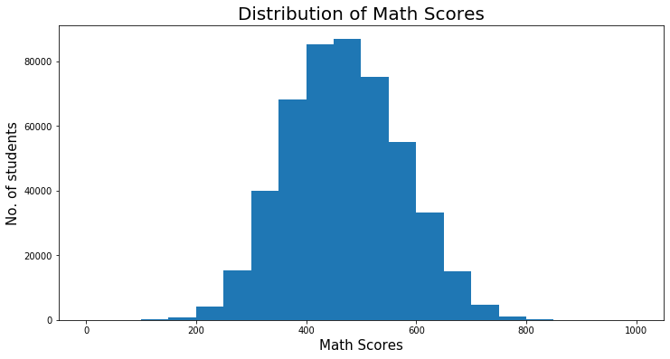

```python
# Distribution of grade scores of Math, Reading and Science
bin_size = np.arange(0, df_clean['math_scores'].max() + 50, 50)

plt.figure(figsize = [12,6])
plt.hist(data = df_clean, x = 'math_scores', bins = bin_size)
plt.xlabel("Math Scores", size = 15)
plt.ylabel("No. of students", size = 15)
plt.title("Distribution of Math Scores", size = 20);
```

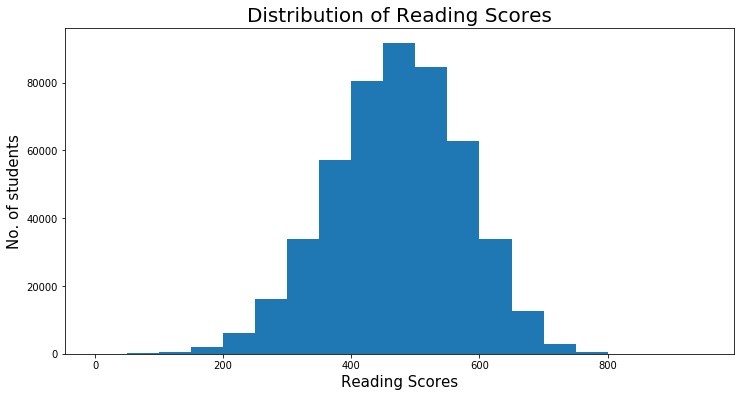

```python
bin_size = np.arange(0, df_clean['reading_scores'].max() + 50, 50)

plt.figure(figsize = [12,6])
plt.hist(data = df_clean, x = 'reading_scores', bins = bin_size)
plt.xlabel("Reading Scores", size = 15)
plt.ylabel("No. of students", size = 15)
plt.title("Distribution of Reading Scores", size = 20);
```

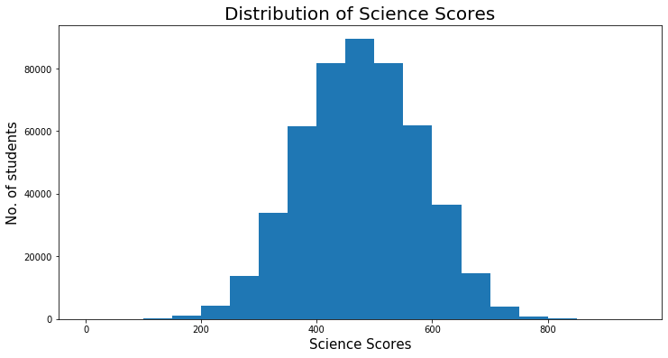

```python
bin_size = np.arange(0, df_clean['science_scores'].max() + 50, 50)

plt.figure(figsize = [12,6])
plt.hist(data = df_clean, x = 'science_scores', bins = bin_size)
plt.xlabel("Science Scores", size = 15)
plt.ylabel("No. of students", size = 15)
plt.title("Distribution of Science Scores", size = 20);
```

*From these plots, it can be clearly observed that all the three grade scores are normally distributed with the peak around 500*

### Wealth Distribution

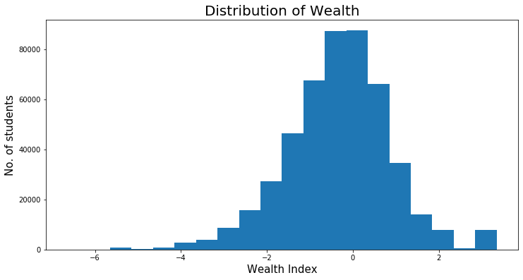

```python
bin_size = np.arange(df_clean['wealth'].min(), df_clean['wealth'].max()+0.5, 0.5)

plt.figure(figsize = [12,6])
plt.hist(data = df_clean, x = 'wealth', bins = bin_size)
plt.xlabel("Wealth Index", size = 15)
plt.ylabel("No. of students", size = 15)
plt.title("Distribution of Wealth", size = 20);
```

**The distribution of wealth is slightly left skewed showing that there are more people with below average wealth**

### Gender Distribution

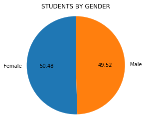

```python
plt.pie(x = df_clean['gender'].value_counts(), labels = df_clean['gender'].value_counts().index, startangle = 90, autopct = '%.2f')
plt.axis('square')
plt.title('STUDENTS BY GENDER');
```

**The pie chart shows almost equal distribution of males and females**

### Parents' Education Distribution

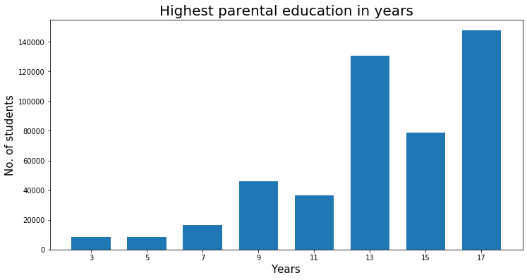

```python
#plot discrete values of parental education years
bins = np.arange(2, df_clean['parental_education'].max()+1, 2)
plt.figure(figsize = [12,6])
plt.hist(data = df_clean, x = 'parental_education', bins = bins, rwidth = 0.7)
plt.xlabel("Years", size = 15)
plt.ylabel("No. of students", size = 15)
plt.title("Highest parental education in years", size = 20)
plt.xticks(np.arange(3, 18, 2));
```

The histogram shows a left skewed bimodal distribution with the peak at around 13 and 17 years.

> **This shows that most of the parents have completed their schooling and with more than 140k parents completing their graduation**

### Distribution by country

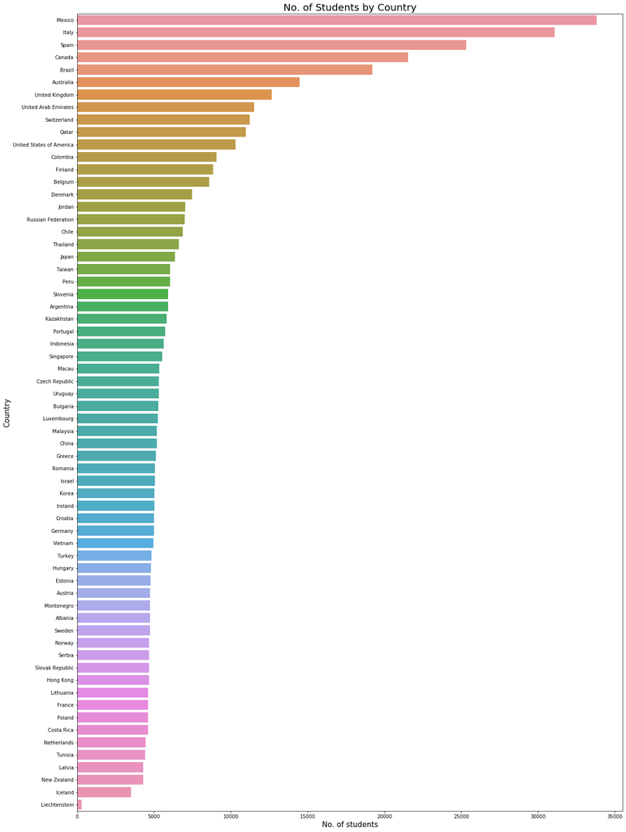

```python
country_order = df_clean['country'].value_counts().index
plt.figure(figsize = [20, 30])
sb.countplot(data = df_clean, y = 'country', order = country_order)
plt.title("No. of Students by Country", size = 20)
plt.xlabel("No. of students", size = 15)
plt.ylabel("Country", size = 15);
```

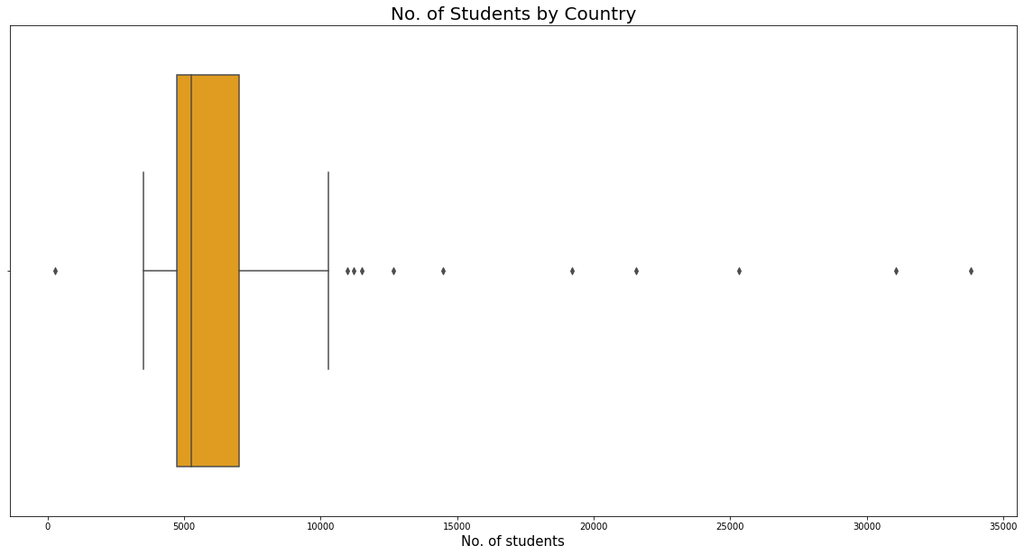

```python
plt.figure(figsize = [20,10])
sb.boxplot(df_clean['country'].value_counts(), color = 'orange')
plt.title("No. of Students by Country", size = 20)
plt.xlabel("No. of students", size = 15);
```

**The two plots for countries show that:**

- Most countries have 5000 - 7000 students taking the test
- There are few outliers such as Mexico and Italy with more than 30000 students and Liechtenstein with less than 1000 students

### Lets look at the top percentile students in Math, distributed by gender

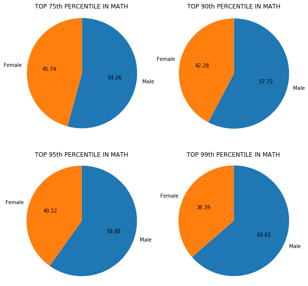

```python
percentile = [75, 90, 95, 99]
fig, axes = plt.subplots(2, 2, figsize = (10, 10))

axes = axes.flatten()

for i in range(4):
    plt.sca(axes[i])
    df = eval('math_' + str(percentile[i]))
    plt.pie(df['gender'].value_counts(), labels = df['gender'].value_counts().index, startangle = 90, autopct = '%.2f', counterclock = False)
    plt.axis('square')
    plt.title('TOP '+ str(percentile[i])+'th PERCENTILE IN MATH')
```

**It is interesting to note that:**

> **As the top percentile increases, the gender gap also increases. Male students generally do better in math**

### Now, lets look at the top percentile students in Reading, distributed by gender, and see if it is any different

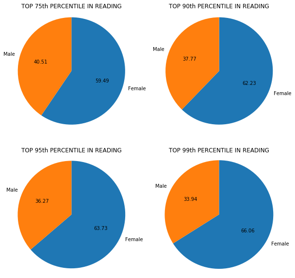

```python
percentile = [75, 90, 95, 99]
fig, axes = plt.subplots(2, 2, figsize = (10, 10))

axes = axes.flatten()

for i in range(4):
    plt.sca(axes[i])
    df = eval('read_' + str(percentile[i]))
    plt.pie(df['gender'].value_counts(), labels = df['gender'].value_counts().index, startangle = 90, autopct = '%.2f', counterclock = False)
    plt.axis('square')
    plt.title('TOP '+ str(percentile[i])+'th PERCENTILE IN READING')
```

**In the case of Reading:**

> **As the top percentile increases, Female students do better than Male**

### Now, lets look at the top percentile students in Science, distributed by gender, and see the results

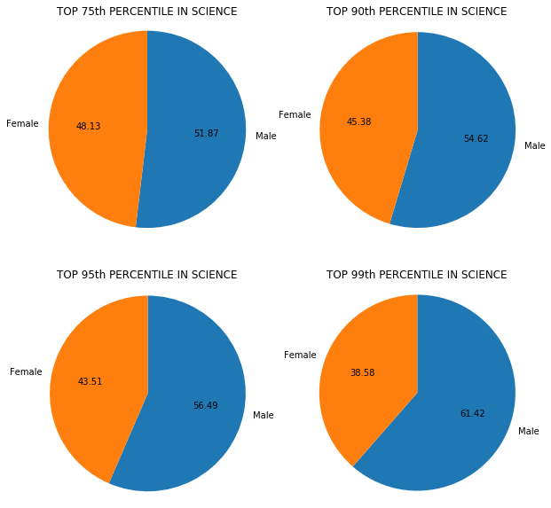

```python
percentile = [75, 90, 95, 99]
fig, axes = plt.subplots(2, 2, figsize = (10, 10))

axes = axes.flatten()

for i in range(4):
    plt.sca(axes[i])
    df = eval('science_' + str(percentile[i]))
    plt.pie(df['gender'].value_counts(), labels = df['gender'].value_counts().index, startangle = 90, autopct = '%.2f', counterclock = False)
    plt.axis('square')
    plt.title('TOP '+ str(percentile[i])+'th PERCENTILE IN SCIENCE')
```

**In the case of Science:**

> **As the top percentile increases, again the Male students do better than Female**

### Personal Traits/characteristics of Students

I am focusing on the below six traits of students

- perseverence
- work ethic of student
- anxiety towards math
- interest in Math
- behaviour towards other activities that enhance Math skills
- motivation for future achievements

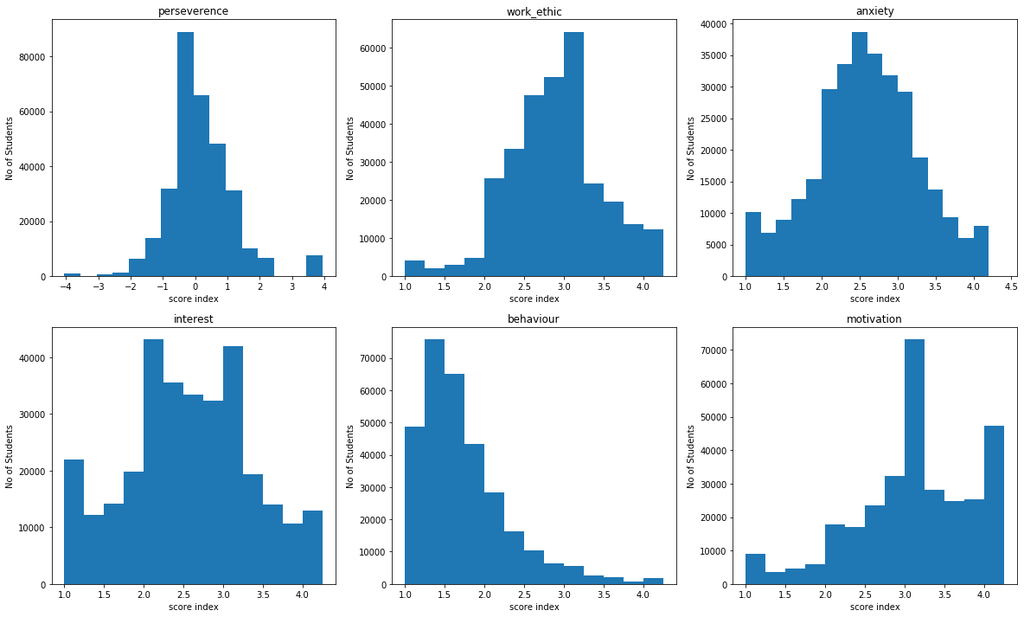

```python
#Plot distribution subplots for each of the trait

plt.figure(figsize = [20, 12]) # larger figure size for subplots


plt.subplot(2, 3, 1) # 2 row, 3 cols, subplot 1
bin_edges1 = np.arange(df_clean['perseverence'].min(), df_clean['perseverence'].max()+0.5, 0.5)
plt.hist(data = df_clean, x = 'perseverence', bins = bin_edges1)
plt.title("perseverence")
plt.xlabel("score index")
plt.ylabel("No of Students")


plt.subplot(2, 3, 2) # 2 row, 3 cols, subplot 2
bin_edges2 = np.arange(df_clean['work_ethic'].min(), df_clean['work_ethic'].max()+0.5, 0.25)
plt.hist(data = df_clean, x = 'work_ethic', bins = bin_edges2)
plt.title("work_ethic")
plt.xlabel("score index")
plt.ylabel("No of Students")

plt.subplot(2, 3, 3) # 2 row, 3 cols, subplot 3
bin_edges3 = np.arange(df_clean['anxiety'].min(), df_clean['anxiety'].max()+0.5, 0.20)
plt.hist(data = df_clean, x = 'anxiety', bins = bin_edges3)
plt.title("anxiety")
plt.xlabel("score index")
plt.ylabel("No of Students")

plt.subplot(2, 3, 4) # 2 row, 3 cols, subplot 4
bin_edges4 = np.arange(df_clean['interest'].min(), df_clean['interest'].max()+0.5, 0.25)
plt.hist(data = df_clean, x = 'interest', bins = bin_edges4)
plt.title("interest")
plt.xlabel("score index")
plt.ylabel("No of Students")

plt.subplot(2, 3, 5) # 2 row, 3 cols, subplot 5
bin_edges5 = np.arange(df_clean['behaviour'].min(), df_clean['behaviour'].max()+0.5, 0.25)
plt.hist(data = df_clean, x = 'behaviour', bins = bin_edges5)
plt.title("behaviour")
plt.xlabel("score index")
plt.ylabel("No of Students");

plt.subplot(2, 3, 6) # 2 row, 3 cols, subplot 6
bin_edges6 = np.arange(df_clean['motivation'].min(), df_clean['motivation'].max()+0.5, 0.25)
plt.hist(data = df_clean, x = 'motivation', bins = bin_edges6)
plt.title("motivation")
plt.xlabel("score index")
plt.ylabel("No of Students");
```

- `perseverence` and `anxiety` are almost normally distributed
- `work_ethic` is slightly skewed to the left with a spike at around 3 points.
- `behaviour` is skewed to the right which shows that most students are not interested in extra activities such as talking about math with friends, playing chess, or computer programming
- `interest` seems bimodal with two peaks at around points 2 and 3.25
- `motivation` seems bimodal and left skewed

### Key insights from Univariate Distribution

> - Male students, on average do better in Math and science whereas Female students perform better in Reading
> - About 5k - 7k students participate from most countries with the exception of some outliers
> - There are multiple types of distributions in the personal traits. It would be interesting to see their relation with grade scores

## Bivariate Exploration

> In this section, we will investigate relationships between pairs of variables in the data.

### Let's see students of which countries have highest average Math scores

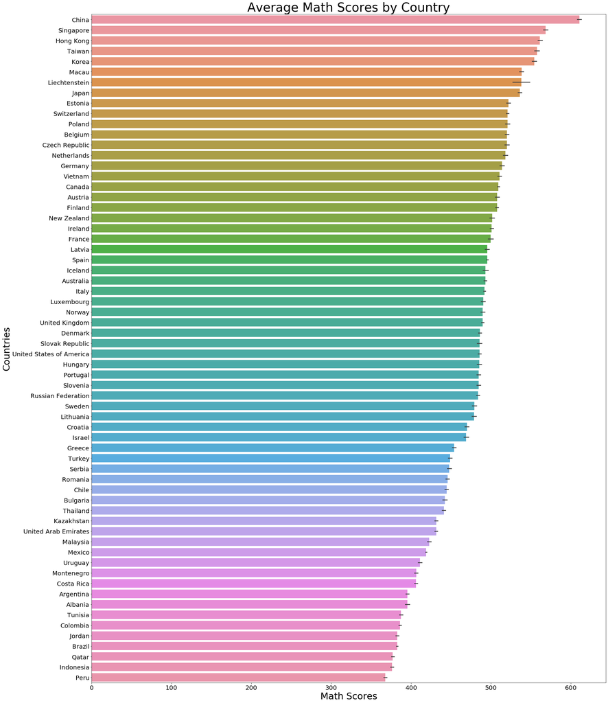

```python
plt.figure(figsize = [30, 40])
b = sb.barplot(data = df_clean, y = 'country', x = 'math_scores', order = order);
b.axes.set_title("Average Math Scores by Country",fontsize=40)
b.set_xlabel("Math Scores",fontsize=30)
b.set_ylabel("Countries",fontsize=30)
b.tick_params(labelsize = 20);
```

**Students from Eastern countries such as China, Taiwan, Singapore, Korea score highest in math on average**

### Now let's check which countries have highest average Reading scores

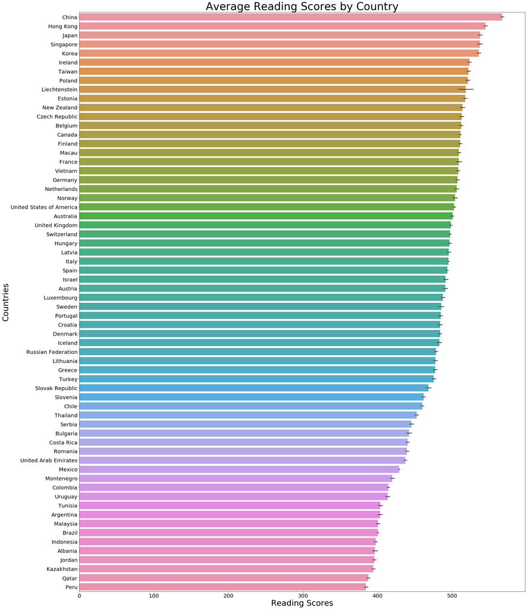

```python
plt.figure(figsize = [30, 40])
b = sb.barplot(data = df_clean, y = 'country', x = 'reading_scores', order = read_order);
b.axes.set_title("Average Reading Scores by Country",fontsize=40)
b.set_xlabel("Reading Scores",fontsize=30)
b.set_ylabel("Countries",fontsize=30)
b.tick_params(labelsize = 20);
```

**Same goes for reading scores as well. Students from eastern countries are much ahead**

### Now, let's check for average science scores by country

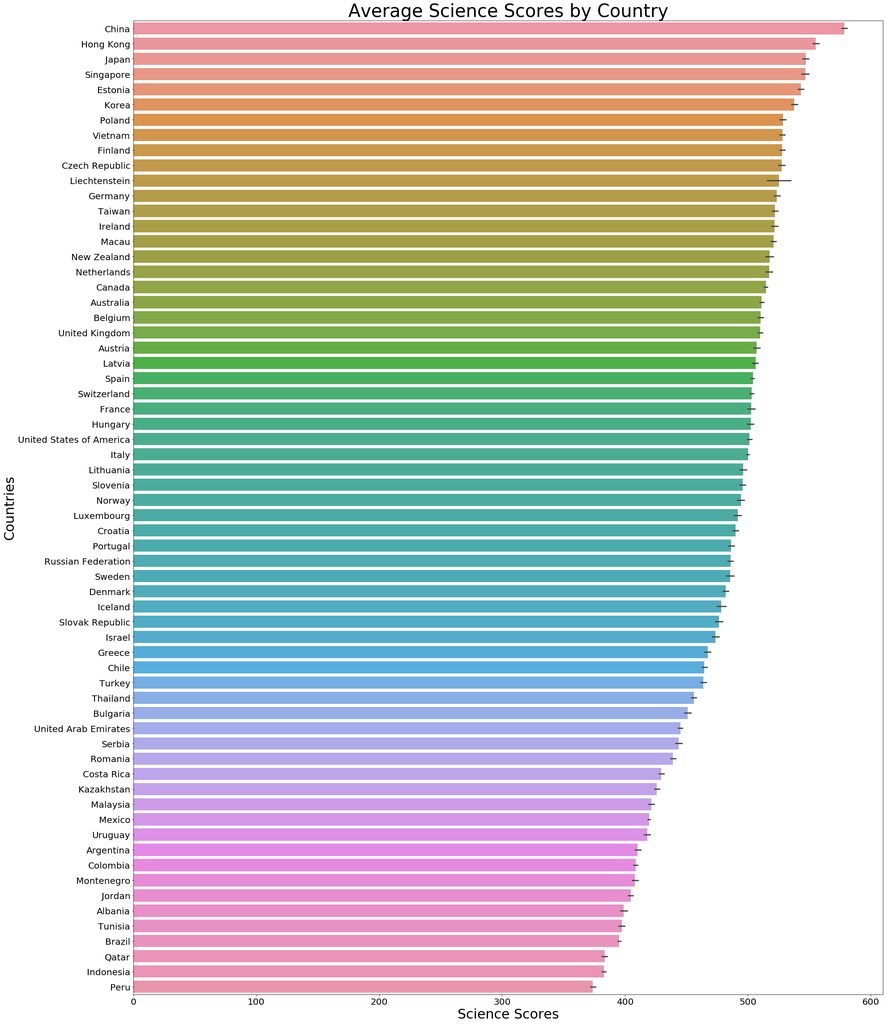

```python
plt.figure(figsize = [30, 40])
b = sb.barplot(data = df_clean, y = 'country', x = 'science_scores', order = sci_order);
b.axes.set_title("Average Science Scores by Country",fontsize=40)
b.set_xlabel("Science Scores",fontsize=30)
b.set_ylabel("Countries",fontsize=30)
b.tick_params(labelsize = 20);
```

### Do students with more wealth score more?

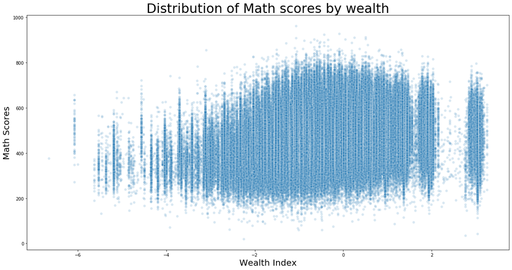

```python
plt.figure(figsize = [20, 10])
sb.scatterplot(data = df_clean, x = 'wealth', y = 'math_scores',
           x_jitter = 0.3, y_jitter = 0.3, alpha =  1/6);
plt.xlabel("Wealth Index", fontsize = 20)
plt.ylabel("Math Scores", fontsize = 20)
plt.title("Distribution of Math scores by wealth", fontsize = 30);
```

**There seems to be some increase in scores as the wealth increases, but it plateaus after a certain level**

### Does the education level of parents affect scores of students?

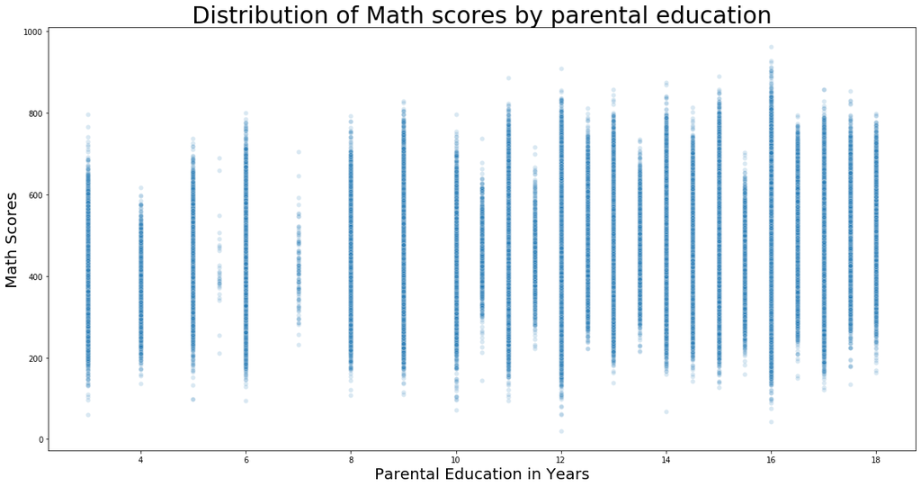

```python
plt.figure(figsize = [20, 10])
sb.scatterplot(data = df_clean, x = 'parental_education', y = 'math_scores',
           x_jitter = 0.3, y_jitter = 0.3, alpha =  1/6);
plt.xlabel("Parental Education in Years", fontsize = 20)
plt.ylabel("Math Scores", fontsize = 20)
plt.title("Distribution of Math scores by parental education", fontsize = 30);
```

### Let's see if students score more if one or both the parents are at home

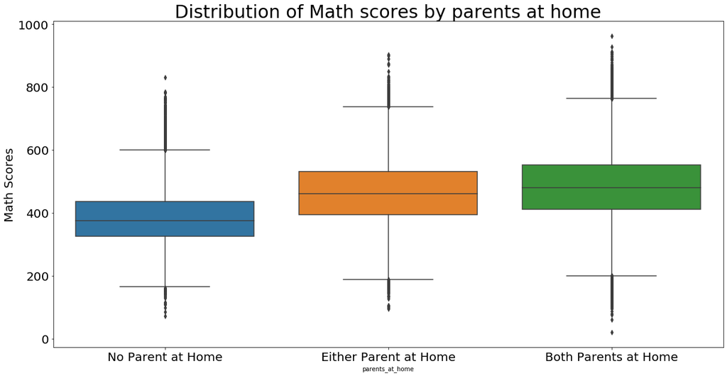

```python
plt.figure(figsize = [20, 10])
b = sb.boxplot(data = df_clean, x = 'parents_at_home', y = 'math_scores')
plt.ylabel("Math Scores", fontsize = 20)
plt.title("Distribution of Math scores by parents at home", fontsize = 30)
plt.xticks([0.0, 1.0, 2.0], ['No Parent at Home', 'Either Parent at Home', 'Both Parents at Home'])
b.tick_params(labelsize = 20);
```

**There is a definite increase in Math Scores with the presence of either one or both the parents at home. The above plot shows the importance of parents in students' grades**

### Math Scores by personal traits

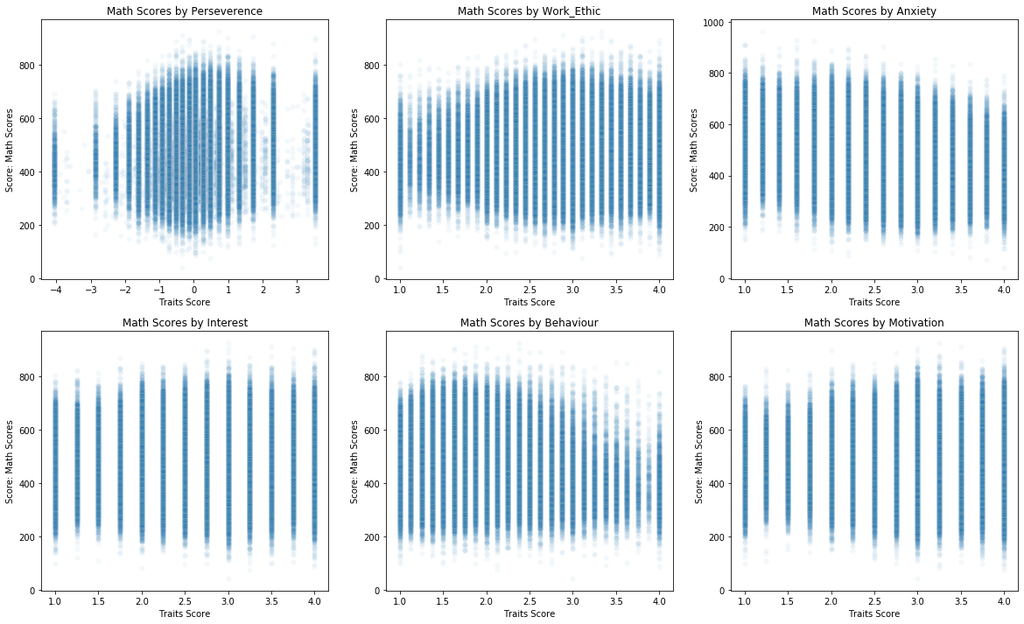

```python
#traits = ['perseverence', 'work_ethic', 'anxiety', 'interest', 'behaviour', 'motivation']

fig, axes = plt.subplots(2, 3, figsize = [20, 12])

axes = axes.flatten() # reshape from 2x3 array into 6-element vector
i = 0

for col in traits:
    plt.sca(axes[i]) # set the current Axes

    sb.scatterplot(x=df_clean[col],y=df_clean['math_scores'],alpha=.05)
    axes[i].set_ylabel('Score: {}'.format('Math Scores'))
    axes[i].set_xlabel('Traits Score')
    axes[i].set_title('Math Scores by {}'.format(col.title()))
    i+=1
```

**Scores of students doesn't seem to be correlated with personal traits based on the above plots**

### How does Teacher relation and support affect grades?

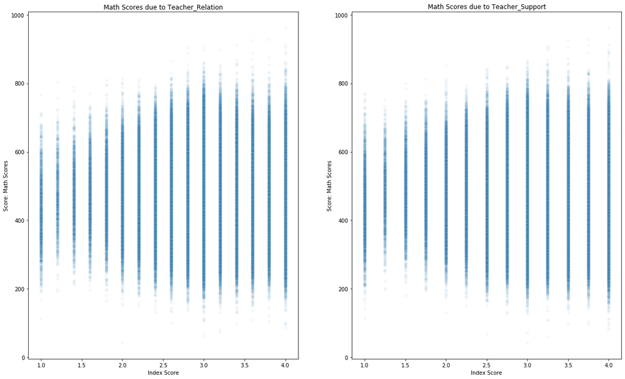

```python
teacher_cols = ['teacher_relation', 'teacher_support']

fig, axes = plt.subplots(1, 2, figsize = [20, 12])

axes = axes.flatten() # reshape from 2x3 array into 6-element vector
i = 0

for col in teacher_cols:
    plt.sca(axes[i]) # set the current Axes

    sb.scatterplot(x=df_clean[col],y=df_clean['math_scores'],alpha=.05)
    axes[i].set_ylabel('Score: {}'.format('Math Scores'))
    axes[i].set_xlabel('Index Score')
    axes[i].set_title('Math Scores due to {}'.format(col.title()))
    i+=1
```

**There seems to be a weak correlation between teacher support and student-teacher relation with Math scores**

## Multivariate Exploration

> Let us now create plots of three or more variables to investigate the data even further.

### Let us see the difference in scores between gender across all the countries

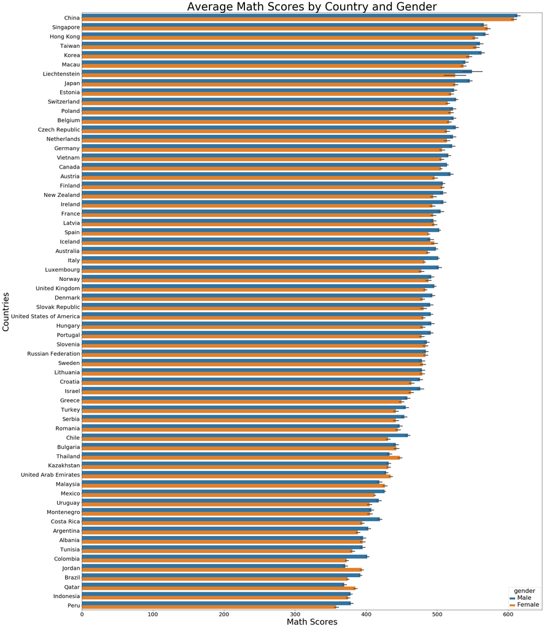

```python
plt.figure(figsize = [30, 40])
b = sb.barplot(data = df_clean, y = 'country', x = 'math_scores', hue = 'gender', order = order, hue_order = ['Male', 'Female']);
b.axes.set_title("Average Math Scores by Country and Gender", fontsize=40)
b.set_xlabel("Math Scores",fontsize=30)
b.set_ylabel("Countries",fontsize=30)
b.tick_params(labelsize = 20)
plt.setp(b.get_legend().get_texts(), fontsize='22') # for legend text
plt.setp(b.get_legend().get_title(), fontsize='22');
```

**Males on average score more than females across most countries**

### Do students scoring high in one subject also score high in other subjects?

Therefore, let us observe the pair-by-pair relationship between Math Scores, Reading Scores and Science Scores, and correlate them in pair scatter plots, in order to see what type and strength of correlation exists.

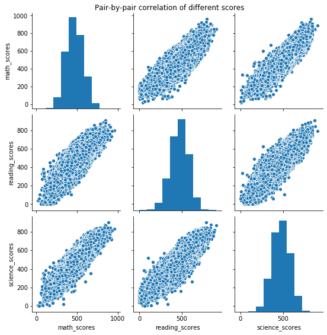

```python
g = sb.pairplot(data = df_clean, vars=["math_scores", "reading_scores", "science_scores"]);
g.fig.suptitle("Pair-by-pair correlation of different scores", y = 1.02);
```

*As expected, there is a very strong and positive correlation between any pair of the three variables representing the scores of the three subjects.*

### Let us now check whether parents staying at home benefits both the gender equally or not

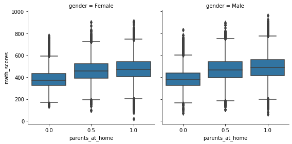

```python
g = sb.FacetGrid(data = df_clean, col = 'gender', size = 4)
g.map(sb.boxplot, 'parents_at_home', 'math_scores');
```

*It can clearly be seen that parents at home benefits both genders equally in terms of grade scores*

### Conclusions

- **How do students from individual countries perform in Math, Reading and Science literacy?**
  - Eastern countries such as China, Singapore, Korea, Hong Kong outperform other countires
- **What is the effect of teachers on student grades?**
  - We could only find a weak positive correlation between teachers and student grades.
- **What is the effect of conducive home environment on student grades?**
  - We discovered that either parent staying at home showed increase in student grades
- **What effect does student's own perseverence and study ethics has on his/her grades?**
  - We could not find any significant impact of personal traits on grades
- **Do grades differ based on gender across subjects in higher percentiles?**
  - We discovered that as the Males perform better in Math and Science where as Females perform better in Reading.